# PUBH 7461 Final Project

Nithya Murikinati, Sri Krishna Vamsi Koneru

2024-12-06

# Dataset

**U.S. National Park Visit Data (1979-2023)**

This dataset contains the number of visits, per month, to each of the current 63 National Parks administered by the United States National Park Service (NPS) from 1979 to 2023. The NPS also collects visitation and use data about other park units, such as national battlefields, national rivers, and national monuments. However, information about other park units is not included in this particular dataset.

The NPS’s visitation data is a valuable resource that gives us a glimpse into the country’s relationship with the National Parks—some of the world’s most precious natural resources—over the last 50 years. This data is integral to the maintenance and growth of the parks, to environmental conservation, to gateway communities, and to our historical and sociological understanding.

The dataset has 12 columns:

```
## 'data.frame':    33395 obs. of  12 variables:
##  $ ParkName           : chr  "Acadia NP" "Acadia NP" "Acadia NP" "Acadia NP" ...
##  $ UnitCode           : chr  "ACAD" "ACAD" "ACAD" "ACAD" ...
##  $ ParkType           : chr  "National Park" "National Park" "National Park" "National Park" ...
##  $ Region             : chr  "Northeast " "Northeast " "Northeast " "Northeast " ...
##  $ State              : chr  "ME" "ME" "ME" "ME" ...
##  $ Year               : int  1979 1979 1979 1979 1979 1979 1979 1979 1979 1979 ...
##  $ Month              : int  1 2 3 4 5 6 7 8 9 10 ...
##  $ RecreationVisits   : int  6011 5243 11165 219351 339416 543205 383341 466928 320138 300976 ...
##  $ NonRecreationVisits: int  15252 13776 15252 37657 50616 70776 41071 50028 34300 32246 ...
##  $ TentCampers        : int  102 53 176 1037 3193 23821 42182 45347 22762 676 ...
##  $ RVCampers          : int  13 8 37 459 1148 9819 23243 23665 15276 422 ...
##  $ Backcountry        : int  0 0 0 0 0 0 0 0 0 0 ...
```

Source: [**U.S. National Park Visit Data**](https://www.responsible-datasets-in-context.com/posts/np-data/)

# Visualization 1

**Question 1: What is the distribution of the types of visits to National Parks over the years?**

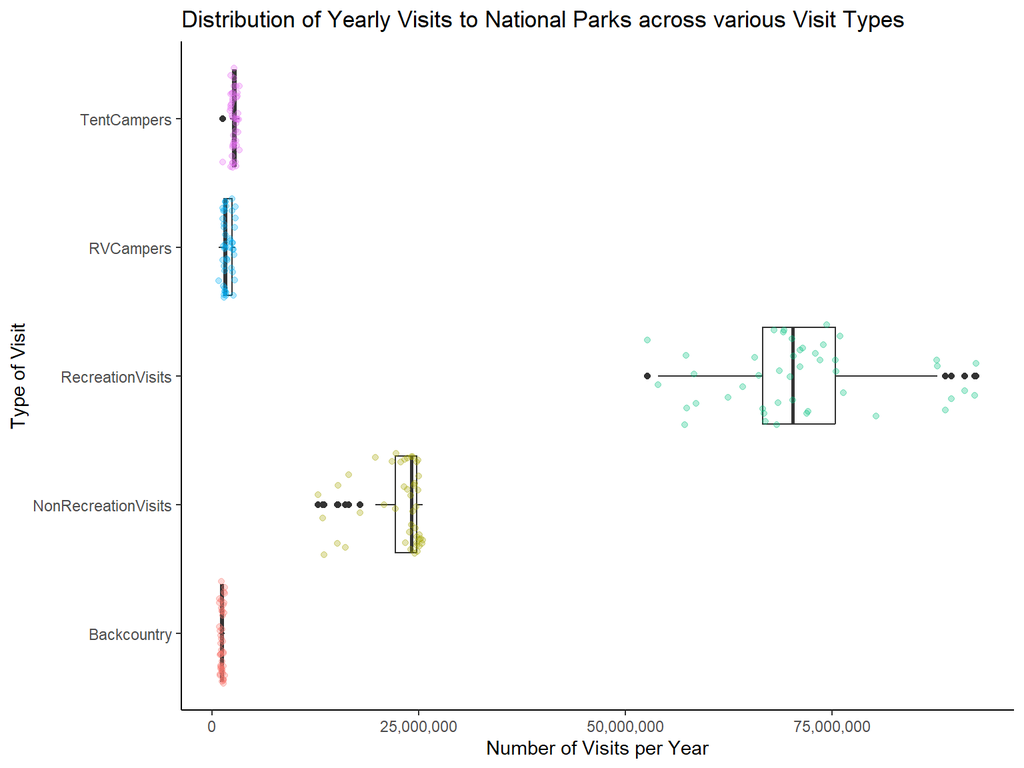

**Interpretation**

- Among the various types of visits to National Parks **Recreational visits** was the most common type, followed by **Non-recreational visits** in the second place.
- The visits of the types: Tent Campers, RV Campers and Backcountry were very few compared to the top two.
- Therefore, let us focus on the recreational and non-recreational visits and explore them further.

# Visualization 2

**Question 2: How have recreation and non-recreation visits to US National Parks evolved over the years?**

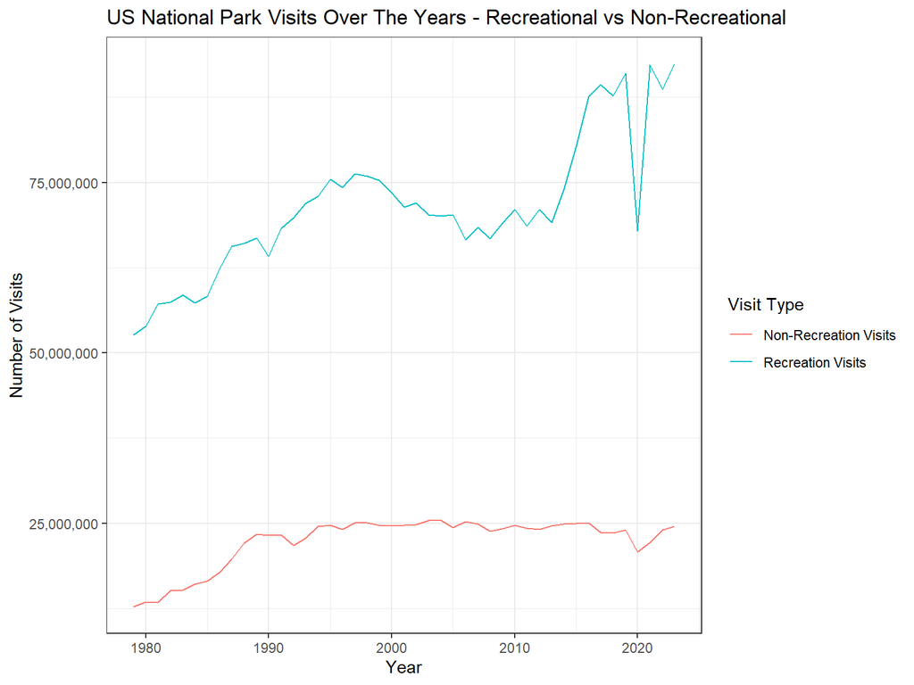

**Interpretation**

- Both recreational and non-recreational visits have shown an increase in the general trend from 1979 to 2023.
- However, there is a drastic decrease in the number of visits for the year **2020**, specifically observed more for recreational visits. One major reason for this downfall could be due to the unexpected COVID-19 pandemic during the start of 2020.
- Hence, let us look at the impact of COVID over US national parks across regions.

# Visualization 3

**Question 3: What is the monthwise trend in recreational visits across regions during 2019, 2020 and 2021?**

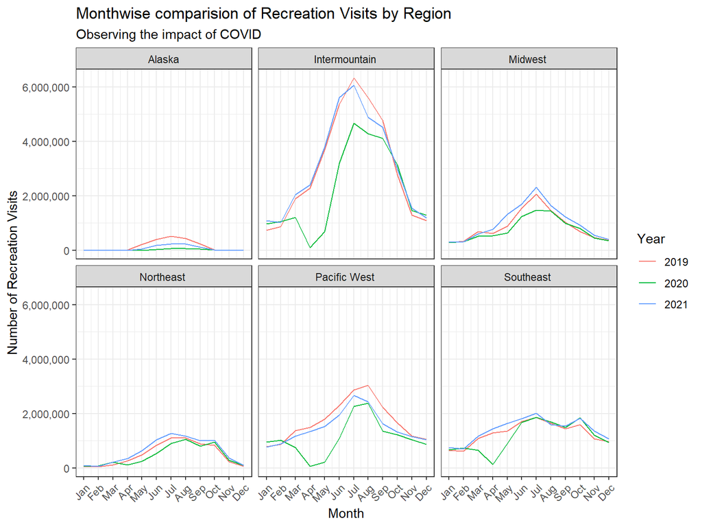

**Interpretation**

# Visualization 4

**Question 4 : How do the number of Recreational and Non Recreational visits look like across different parks in the Intermountain region during 2019-2021?**

Number of Visits to National Parks in Intermountain Region during 2019-2021

|  | National Park | Recreation Visits 2019 | Recreation Visits 2020 | Recreation Visits 2021 | Non Recreation Visits 2019 | Non Recreation Visits 2020 | Non Recreation Visits 2021 |
| --- | --- | --- | --- | --- | --- | --- | --- |
| 1 | Arches NP | 1659702 | 1238083 | 1806865 | 0 | 0 | 0 |
| 2 | Big Bend NP | 463832 | 393907 | 581220 | 2364 | 2364 | 2364 |
| 3 | Black Canyon of the Gunnison NP | 432818 | 341620 | 308910 | 0 | 0 | 0 |
| 4 | Bryce Canyon NP | 2594904 | 1464655 | 2104600 | 416166 | 412465 | 445652 |
| 5 | Canyonlands NP | 733996 | 493914 | 911594 | 0 | 0 | 0 |
| 6 | Capitol Reef NP | 1226519 | 981038 | 1405353 | 56871 | 66851 | 54763 |
| 7 | Carlsbad Caverns NP | 440691 | 183835 | 349244 | 0 | 0 | 0 |
| 8 | Glacier NP | 3049839 | 1698864 | 3081656 | 13103 | 0 | 7986 |
| 9 | Grand Canyon NP | 5974411 | 2897098 | 4532677 | 21249 | 14788 | 18243 |
| 10 | Grand Teton NP | 3405614 | 3289638 | 3885230 | 1610087 | 1220029 | 1587871 |
| 11 | Great Sand Dunes NP & PRES | 527546 | 461532 | 602613 | 470 | 470 | 470 |
| 12 | Guadalupe Mountains NP | 188833 | 151256 | 243291 | 1440 | 1440 | 1440 |
| 13 | Mesa Verde NP | 556203 | 287477 | 548477 | 10081 | 7519 | 13510 |
| 14 | Petrified Forest NP | 643588 | 384483 | 590334 | 120 | 120 | 120 |
| 15 | Rocky Mountain NP | 4670053 | 3305199 | 4434848 | 8750 | 8750 | 8750 |
| 16 | Saguaro NP | 1020226 | 762226 | 1079786 | 2694738 | 2897233 | 2931086 |
| 17 | White Sands NP | 608785 | 415383 | 782469 | 0 | 0 | 0 |
| 18 | Yellowstone NP | 4020288 | 3806306 | 4860242 | 1187528 | 1122445 | 1329368 |
| 19 | Zion NP | 4488268 | 3591254 | 5039835 | 21900 | 21900 | 21900 |

Data source: U.S. NATIONAL PARK VISIT DATA(1979-2023)

# Future Work

- Bar graphs could be created faceted for each national park in a specific region. This would help in identifying region specific trendsover the visits.
- The analysis that we did for intermountain region could be reproduced on other regions and an interesting topic would be to study and compare the percentage of visits reduced due to COVID over all regions.
- Another intriguing area of research could be observing the trends of RV Campers, Tent Campers and Backcountry visits across the national parks in US. This can be further extended to region specific visualizations.
- Overall, our analysis can act as a foundation for the NPS officials to understand the impact of COVID over US national parks and make data driven decisions accordingly.

# References

- https://www.responsible-datasets-in-context.com/posts/np-data/
- https://tidyr.tidyverse.org/
- https://cran.r-project.org/web/packages/ggplot2/index.html
- https://gt.rstudio.com/
- [PUBH 7461 Coursework](https://canvas.umn.edu/courses/462619)